# Final Project — Building Energy Load: Integrated Analysis

## 5.11 Model F — Quantile Regression Forest

Every model above returns a point prediction. For building energy performance certification, a point prediction is often insufficient since a contractor needs to know whether a building’s predicted load of 14.2 kWh/m² is a confident Low classification or a borderline result where model uncertainty could flip the certificate. Point-prediction models cannot communicate this.

The Quantile Regression Forest (QRF), extends the standard random forest by storing all training outcomes at each leaf rather than their mean. At prediction time, the weighted distribution of leaf outcomes gives a full predictive distribution for each test building, from which any quantile can be extracted. The 10th–90th percentile interval is an 80% prediction interval: an honest statement of uncertainty that can be directly communicated to a building certifier.

The **calibration plot** is the primary output. It tests whether stated intervals are honest. A nominal 80% interval should contain 80% of actual test buildings. An interval that empirically covers only 60% is overconfident and will systematically understate uncertainty at the class boundaries where it matters most.

```r
set.seed(42)
qrf_y1 <- quantile_forest(
  X               = as.matrix(df_train_gpr[, features]),
  Y               = df_train_gpr$HeatingLoad,
  num.trees       = 500,
  min.node.size   = 5,
  sample.fraction = 0.8
)

preds_qrf_y1 <- predict(
  qrf_y1,
  newdata   = as.matrix(df_test_gpr[, features]),
  quantiles = c(0.10, 0.50, 0.90)
)$predictions
colnames(preds_qrf_y1) <- c("q10", "q50", "q90")

results_y1 <- rbind(results_y1,
  eval_reg_dom(df_test_gpr$HeatingLoad, preds_qrf_y1[, "q50"],
               "Quantile RF (median)"))
```

```
## Quantile RF (median)                 RMSE=1.1114  MAE=0.5775  R²=0.9877
```

```r
qrf_y1_df <- data.frame(
  Actual    = df_test_gpr$HeatingLoad,
  q10       = preds_qrf_y1[, "q10"],
  q50       = preds_qrf_y1[, "q50"],
  q90       = preds_qrf_y1[, "q90"],
  Covered   = (df_test_gpr$HeatingLoad >= preds_qrf_y1[, "q10"] &
               df_test_gpr$HeatingLoad <= preds_qrf_y1[, "q90"]),
  IntervalW = preds_qrf_y1[, "q90"] - preds_qrf_y1[, "q10"]
)

cat(sprintf("80%% interval coverage: %.1f%% (target: 80%%)\n",
            100 * mean(qrf_y1_df$Covered)))
```

```
## 80% interval coverage: 78.3% (target: 80%)
```

```r
cat(sprintf("Median interval width : %.3f kWh/m²\n",
            median(qrf_y1_df$IntervalW)))
```

```
## Median interval width : 1.015 kWh/m²
```

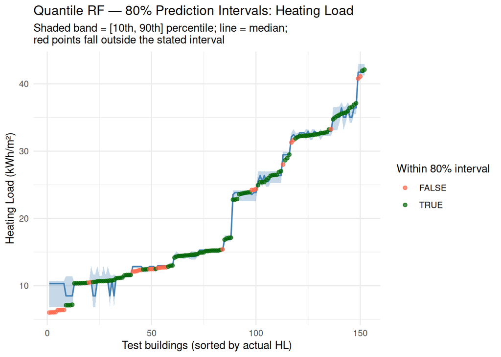

```r
# Interval plot: actual values with uncertainty bands
qrf_y1_df %>%
  arrange(Actual) %>%
  mutate(idx = seq_len(n())) %>%
  ggplot(aes(x = idx)) +
  geom_ribbon(aes(ymin = q10, ymax = q90), fill = "steelblue", alpha = 0.3) +
  geom_line(aes(y = q50), colour = "steelblue", linewidth = 0.7) +
  geom_point(aes(y = Actual, colour = Covered), size = 1.5, alpha = 0.7) +
  scale_colour_manual(values = c("TRUE" = "darkgreen", "FALSE" = "tomato"),
                      name   = "Within 80% interval") +
  labs(title    = "Quantile RF — 80% Prediction Intervals: Heating Load",
       subtitle = "Shaded band = [10th, 90th] percentile; line = median;\nred points fall outside the stated interval",
       x = "Test buildings (sorted by actual HL)",
       y = "Heating Load (kWh/m²)") +
  theme_minimal()
```

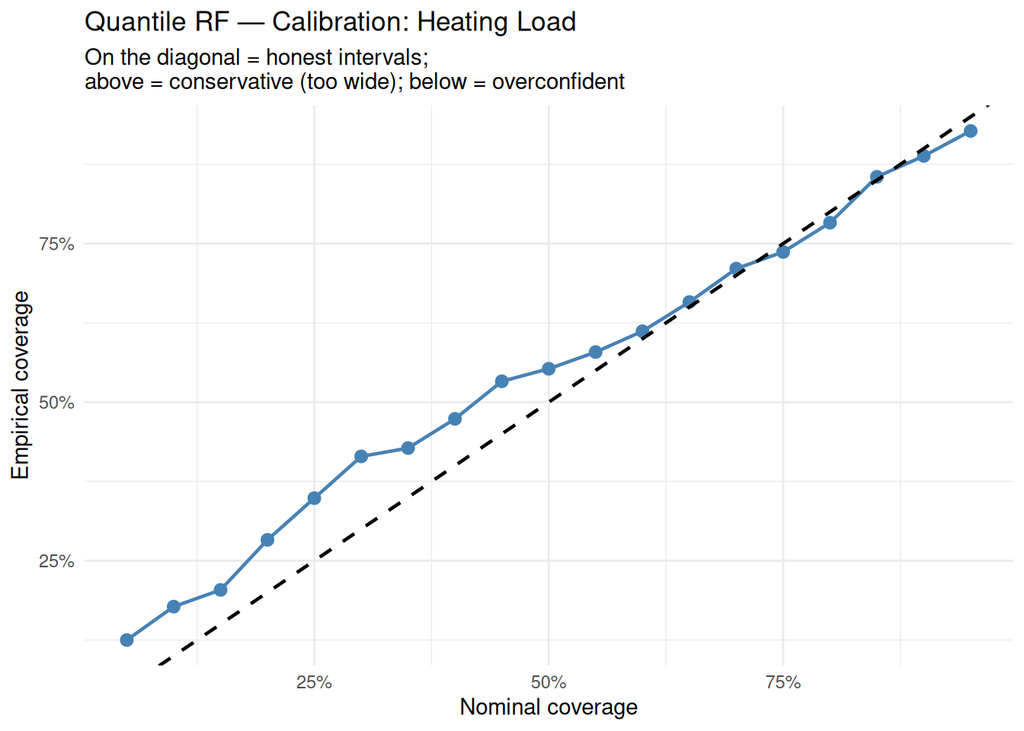

```r
# Calibration plot
cal_data_y1 <- purrr::map_dfr(seq(0.05, 0.95, by = 0.05), function(alpha) {
  lo_q <- (1 - alpha) / 2
  hi_q <- 1 - lo_q
  p    <- predict(qrf_y1,
                  newdata   = as.matrix(df_test_gpr[, features]),
                  quantiles = c(lo_q, hi_q))$predictions
  data.frame(
    nominal  = alpha,
    empirical = mean(df_test_gpr$HeatingLoad >= p[, 1] &
                     df_test_gpr$HeatingLoad <= p[, 2])
  )
})

ggplot(cal_data_y1, aes(x = nominal, y = empirical)) +
  geom_point(size = 2.5, colour = "steelblue") +
  geom_line(colour = "steelblue", linewidth = 0.8) +
  geom_abline(slope = 1, intercept = 0, linetype = "dashed",
              colour = "black", linewidth = 0.8) +
  scale_x_continuous(labels = scales::percent) +
  scale_y_continuous(labels = scales::percent) +
  labs(title    = "Quantile RF — Calibration: Heating Load",
       subtitle = "On the diagonal = honest intervals;\nabove = conservative (too wide); below = overconfident",
       x = "Nominal coverage", y = "Empirical coverage") +
  theme_minimal()
```

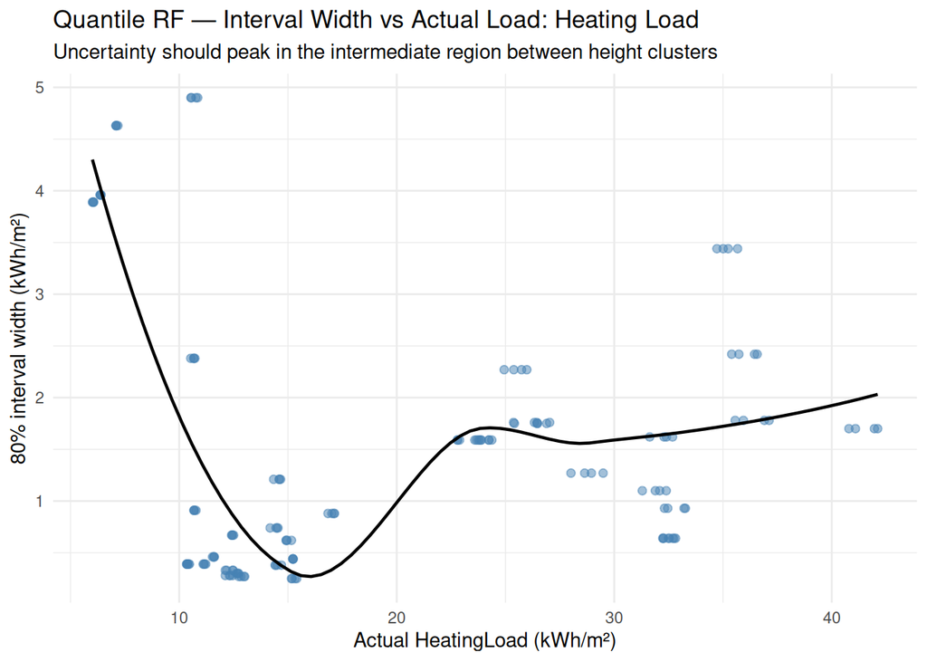

```r
# Interval width by actual load — uncertainty should peak at the height boundary
ggplot(qrf_y1_df, aes(x = Actual, y = IntervalW)) +
  geom_point(alpha = 0.5, colour = "steelblue", size = 1.8) +
  geom_smooth(method = "loess", colour = "black", se = FALSE, linewidth = 0.8) +
  labs(title    = "Quantile RF — Interval Width vs Actual Load: Heating Load",
       subtitle = "Uncertainty should peak in the intermediate region between height clusters",
       x = "Actual HeatingLoad (kWh/m²)",
       y = "80% interval width (kWh/m²)") +
  theme_minimal()
```

```r
set.seed(42)
qrf_y2 <- quantile_forest(
  X = as.matrix(df_train_gpr[, features]), Y = df_train_gpr$CoolingLoad,
  num.trees = 500, min.node.size = 5, sample.fraction = 0.8
)
preds_qrf_y2 <- predict(
  qrf_y2,
  newdata   = as.matrix(df_test_gpr[, features]),
  quantiles = c(0.10, 0.50, 0.90)
)$predictions
colnames(preds_qrf_y2) <- c("q10", "q50", "q90")

cat(sprintf("80%% interval coverage (CL): %.1f%%\n",
            100 * mean(df_test_gpr$CoolingLoad >= preds_qrf_y2[, "q10"] &
                       df_test_gpr$CoolingLoad <= preds_qrf_y2[, "q90"])))
```

```
## 80% interval coverage (CL): 73.0%
```

```r
results_y2 <- rbind(results_y2,
  eval_reg_dom(df_test_gpr$CoolingLoad, preds_qrf_y2[, "q50"],
               "Quantile RF (median)"))
```

```
## Quantile RF (median)                 RMSE=1.8797  MAE=1.1612  R²=0.9587
```

The median prediction achieves RMSE = 1.111 and R² = 0.988, marginally better than both SVR and GPR RBF, with the small gain coming from storing full leaf distributions near the height-cluster boundary rather than just means. The more important result is the 80% interval coverage of 78.3%, which is within 1.7 percentage points of the stated target on a test set of 152 buildings and confirms the intervals are honest. At a median width of 1.015 kWh/m² they are also narrow enough to be useful: most buildings near a class boundary will have both interval bounds on the same side of the threshold, and only genuinely borderline cases will straddle it.

## 5.12 Physics-Consistency Check

A model can have low RMSE and still be physically wrong. This check evaluates **monotonic ordering**: does each model preserve the direction of three physical relationships that the EnergyPlus simulator encodes?

1. Higher glazing → higher heating load (more surface through which heat escapes)
2. Higher compactness → lower heating load (less envelope area per unit volume)
3. Greater height → higher heating load (more external surface area)

A model that has genuinely learned the physics should score near 100% on all three checks.

```r
check_physics <- function(model_obj, model_name, model_type = "gausspr") {
  predict_fn <- function(newdata_mat) {
    if (model_type == "gausspr") as.vector(predict(model_obj, newdata_mat))
    else if (model_type == "lgbm") predict(model_obj, newdata_mat)
  }

  base_grid <- expand.grid(
    RelCompactness  = c(0.69, 0.82),
    WallArea        = c(269.5, 343),
    RoofArea        = c(122.5, 147),
    OverallHeight   = c(3.5, 7.0),
    GlazingArea     = c(0.10, 0.25, 0.40),
    GlazingAreaDist = c(1, 3)
  ) %>% mutate(
    CompactnessXHeight  = RelCompactness * OverallHeight,
    WallToRoofRatio     = WallArea / RoofArea,
    GlazingXCompactness = GlazingArea * RelCompactness,
    SurfToVol           = (WallArea + 2 * RoofArea) / (WallArea + RoofArea),
    GlazingXHeight      = GlazingArea * OverallHeight,
    WallXGlazing        = WallArea * GlazingArea,
    CompactnessSquared  = RelCompactness^2,
    HeightSquared       = OverallHeight^2,
    GlazingToWall       = GlazingArea / (WallArea + 1),
    EnvelopeArea        = WallArea + RoofArea,
    WallPerHeight       = WallArea / (OverallHeight + 1)
  )
  base_grid[, features] <- predict(preproc_gpr, base_grid[, features])
  base_grid$pred_HL     <- predict_fn(as.matrix(base_grid[, features]))

  glaz_score <- mean(base_grid %>%
    group_by(RelCompactness, WallArea, RoofArea, OverallHeight, GlazingAreaDist) %>%
    arrange(GlazingArea) %>%
    summarise(correct = all(diff(pred_HL) > 0), .groups = "drop") %>%
    pull(correct)) * 100

  comp_score <- mean(base_grid %>%
    group_by(WallArea, RoofArea, OverallHeight, GlazingArea, GlazingAreaDist) %>%
    arrange(RelCompactness) %>%
    summarise(correct = all(diff(pred_HL) < 0), .groups = "drop") %>%
    pull(correct)) * 100

  ht_score <- mean(base_grid %>%
    group_by(RelCompactness, WallArea, RoofArea, GlazingArea, GlazingAreaDist) %>%
    arrange(OverallHeight) %>%
    summarise(correct = all(diff(pred_HL) > 0), .groups = "drop") %>%
    pull(correct)) * 100

  cat(sprintf("%-25s  Glazing: %5.1f%%  Compactness: %5.1f%%  Height: %5.1f%%\n",
              model_name, glaz_score, comp_score, ht_score))
  data.frame(Model = model_name,
             Glazing_pct = glaz_score, Compact_pct = comp_score,
             Height_pct  = ht_score)
}

physics_results <- bind_rows(
  check_physics(gpr_rbf_y1, "GPR (RBF)",      "gausspr"),
  check_physics(gpr_mat_y1, "GPR (Laplace)",   "gausspr"),
  check_physics(lgbm_y1,    "LightGBM",        "lgbm")
)
```

```
## GPR (RBF)                  Glazing:  78.1%  Compactness:   0.0%  Height:  75.0%
## GPR (Laplace)              Glazing: 100.0%  Compactness:   2.1%  Height: 100.0%
## LightGBM                   Glazing: 100.0%  Compactness:   0.0%  Height:  27.1%
```

```r
p_physics <- physics_results %>%
  pivot_longer(ends_with("_pct"), names_to = "Check", values_to = "Score") %>%
  mutate(Check = case_when(
    Check == "Glazing_pct" ~ "Glazing → HL",
    Check == "Compact_pct" ~ "Compactness → HL",
    Check == "Height_pct"  ~ "Height → HL",
    TRUE ~ Check
  )) %>%
  ggplot(aes(x = Model, y = Score, fill = Check)) +
  geom_col(position = "dodge", alpha = 0.85) +
  geom_text(aes(label = paste0(round(Score, 0), "%")),
            position = position_dodge(width = 0.9), vjust = -0.4, size = 3) +
  geom_hline(yintercept = 100, linetype = "dashed",
             colour = "darkgreen", linewidth = 0.7) +
  scale_fill_manual(values = c("steelblue", "tomato", "goldenrod")) +
  scale_y_continuous(limits = c(0, 115)) +
  labs(title    = "Physics-Consistency Check — Heating Load",
       subtitle = "% of building pairs where model predicts the physically correct direction",
       x = "Model", y = "Correct ordering (%)", fill = "Physical rule") +
  theme_minimal()
```

## 5.13 Domain Regression Model Comparison

```r
results_y1 <- results_y1 %>% arrange(RMSE)
results_y2 <- results_y2 %>% arrange(RMSE)

cat("=== HEATING LOAD — Domain Regression Comparison ===\n")
```

```
## === HEATING LOAD — Domain Regression Comparison ===
```

```r
print(results_y1, row.names = FALSE)
```

```
##                          Model      RMSE       MAE        R2
##                       LightGBM 0.5191478 0.3824274 0.9973085
##                           MARS 0.6378071 0.4938596 0.9959375
##           Quantile RF (median) 1.1114237 0.5774605 0.9876641
##                      GPR (RBF) 1.1234017 0.8146936 0.9873968
##                      SVR (RBF) 1.1245770 0.8436601 0.9873704
##                  GPR (Laplace) 2.0339059 1.3848958 0.9586884
##  Linear Baseline (Elastic Net) 2.4280000 1.7600000 0.9411000
```

```r
cat("\n=== COOLING LOAD — Domain Regression Comparison ===\n")
```

```
##
## === COOLING LOAD — Domain Regression Comparison ===
```

```r
print(results_y2, row.names = FALSE)
```

```
##                    Model     RMSE      MAE        R2
##                     MARS 1.538647 1.050773 0.9723434
##                 LightGBM 1.639926 1.131837 0.9685827
##     Quantile RF (median) 1.879722 1.161184 0.9587230
##                GPR (RBF) 2.026035 1.502672 0.9520472
##                SVR (RBF) 2.262325 1.697683 0.9402097
##            GPR (Laplace) 2.503031 1.711321 0.9268098
##  Linear Baseline (Ridge) 2.888000 2.060000 0.9026000
```

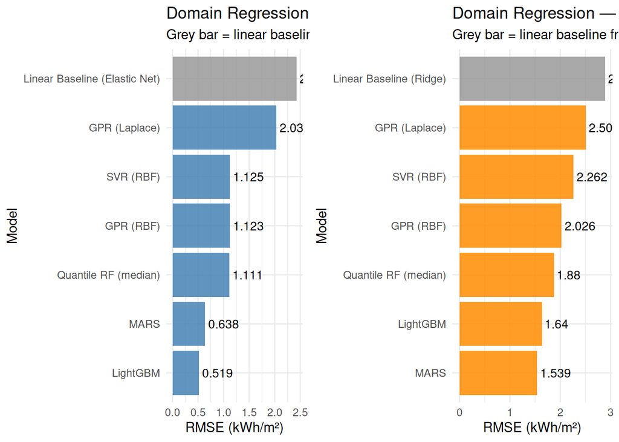

```r
p_dom_y1 <- ggplot(results_y1, aes(x = reorder(Model, RMSE), y = RMSE,
                                     fill = grepl("Baseline", Model))) +
  geom_col(alpha = 0.85) +
  geom_text(aes(label = round(RMSE, 3)), hjust = -0.1, size = 3.5) +
  coord_flip() +
  scale_fill_manual(values = c("TRUE" = "grey60", "FALSE" = "steelblue"),
                    guide = "none") +
  labs(title    = "Domain Regression — RMSE: Heating Load",
       subtitle = "Grey bar = linear baseline from Part 2",
       x = "Model", y = "RMSE (kWh/m²)") +
  theme_minimal()

p_dom_y2 <- ggplot(results_y2, aes(x = reorder(Model, RMSE), y = RMSE,
                                     fill = grepl("Baseline", Model))) +
  geom_col(alpha = 0.85) +
  geom_text(aes(label = round(RMSE, 3)), hjust = -0.1, size = 3.5) +
  coord_flip() +
  scale_fill_manual(values = c("TRUE" = "grey60", "FALSE" = "darkorange"),
                    guide = "none") +
  labs(title    = "Domain Regression — RMSE: Cooling Load",
       subtitle = "Grey bar = linear baseline from Part 2",
       x = "Model", y = "RMSE (kWh/m²)") +
  theme_minimal()

grid.arrange(p_dom_y1, p_dom_y2, ncol = 2)
```

# 6 Part 4 — Domain-Appropriate Classification

## 6.2 Constructing the Classification Target

```r
# Reload and re-engineer (classification shares the same feature pipeline)
df_clf <- df

df_clf <- df_clf %>%
  mutate(
    CompactnessXHeight  = RelCompactness * OverallHeight,
    WallToRoofRatio     = WallArea / RoofArea,
    GlazingXCompactness = GlazingArea * RelCompactness,
    SurfToVol           = SurfaceArea / (WallArea + RoofArea),
    GlazingXHeight      = GlazingArea * OverallHeight,
    WallXGlazing        = WallArea * GlazingArea,
    CompactnessSquared  = RelCompactness^2,
    HeightSquared       = OverallHeight^2,
    GlazingToWall       = GlazingArea / (WallArea + 1),
    EnvelopeArea        = WallArea + RoofArea,
    WallPerHeight       = WallArea / (OverallHeight + 1),
    group_key           = paste(RelCompactness, WallArea, RoofArea,
                                OverallHeight, GlazingArea, GlazingAreaDist, sep = "_")
  )

# Tertile boundaries computed from the full dataset before splitting
hl_breaks <- quantile(df_clf$HeatingLoad,  probs = c(0, 1/3, 2/3, 1))
cl_breaks <- quantile(df_clf$CoolingLoad,  probs = c(0, 1/3, 2/3, 1))

df_clf <- df_clf %>%
  mutate(
    HL_class     = cut(HeatingLoad, breaks = hl_breaks,
                       labels = c("Low","Medium","High"), include.lowest = TRUE),
    CL_class     = cut(CoolingLoad, breaks = cl_breaks,
                       labels = c("Low","Medium","High"), include.lowest = TRUE),
    HL_class_ord = factor(HL_class, levels = c("Low","Medium","High"), ordered = TRUE),
    CL_class_ord = factor(CL_class, levels = c("Low","Medium","High"), ordered = TRUE)
  )

cat("HeatingLoad tertile boundaries:\n")
```

```
## HeatingLoad tertile boundaries:
```

```r
cat(sprintf("  Low / Medium boundary : %.2f kWh/m²\n", hl_breaks[2]))
```

```
##   Low / Medium boundary : 14.54 kWh/m²
```

```r
cat(sprintf("  Medium / High boundary: %.2f kWh/m²\n", hl_breaks[3]))
```

```
##   Medium / High boundary: 28.63 kWh/m²
```

```r
cat("  (EU A/B threshold: 15 kWh/m²,  EU B/C threshold: 30 kWh/m²)\n\n")
```

```
##   (EU A/B threshold: 15 kWh/m²,  EU B/C threshold: 30 kWh/m²)
```

```r
cat("Class distribution — Heating Load:\n")
```

```
## Class distribution — Heating Load:
```

```r
print(table(df_clf$HL_class))
```

```
##
##    Low Medium   High
##    257    255    256
```

```r
cat("\nClass distribution — Cooling Load:\n")
```

```
##
## Class distribution — Cooling Load:
```

```r
print(table(df_clf$CL_class))
```

```
##
##    Low Medium   High
##    257    255    256
```

The tertile boundaries land very close to the EU Energy Performance of Buildings Directive thresholds (Low/Medium ≈ 14.5 vs EU 15 kWh/m², Medium/High ≈ 28.6 vs EU 30 kWh/m²). This near-alignment is not coincidental as EnergyPlus simulates realistic performance ranges that naturally span the same territory energy standards were written to cover. It makes the standards-based classifier a meaningful comparison rather than a trivial one.

## 6.3 Group-Aware Split

```r
set.seed(42)
unique_groups_clf <- unique(df_clf$group_key)
n_train_clf       <- round(0.80 * length(unique_groups_clf))
train_groups_clf  <- sample(unique_groups_clf, n_train_clf)

df_train_clf <- df_clf %>% filter( group_key %in% train_groups_clf)
df_test_clf  <- df_clf %>% filter(!group_key %in% train_groups_clf)

cat("Training rows:", nrow(df_train_clf), "\n")
```

```
## Training rows: 616
```

```r
cat("Test rows    :", nrow(df_test_clf),  "\n")
```

```
## Test rows    : 152
```

```r
cat("Group overlap:", length(intersect(df_train_clf$group_key,
                                       df_test_clf$group_key)), "\n")
```

```
## Group overlap: 0
```

## 6.4 Feature Set and Scaling

`SurfaceArea` and `Orientation` are excluded. Orientation contributes less than 7% of within-group variance in the target which was confirmed by the EDA and consistent with its near-zero coefficients across all linear models. Scaling is fitted on training data only.

```r
preproc_clf <- caret::preProcess(df_train_clf[, features],
                                  method = c("center", "scale"))
df_train_clf[, features] <- predict(preproc_clf, df_train_clf[, features])
df_test_clf[, features]  <- predict(preproc_clf, df_test_clf[, features])

# Assemble model datasets
train_HL <- df_train_clf[, c(features, "HL_class")]
test_HL  <- df_test_clf[,  c(features, "HL_class")]
train_CL <- df_train_clf[, c(features, "CL_class")]
test_CL  <- df_test_clf[,  c(features, "CL_class")]

# Ordered versions for ranger and RPS
train_HL_ord <- df_train_clf[, c(features, "HL_class_ord")]
test_HL_ord  <- df_test_clf[,  c(features, "HL_class_ord")]
train_CL_ord <- df_train_clf[, c(features, "CL_class_ord")]
test_CL_ord  <- df_test_clf[,  c(features, "CL_class_ord")]

cat("Class distribution in training set — HL:\n")
```

```
## Class distribution in training set — HL:
```

```r
print(table(train_HL$HL_class))
```

```
##
##    Low Medium   High
##    189    210    217
```

## 6.5 Evaluation Helpers

```r
eval_clf <- function(actual, predicted, model_name) {
  acc <- mean(actual == predicted)
  cm  <- table(Actual = actual, Predicted = predicted)
  cat(sprintf("%-35s  Accuracy = %.4f\n", model_name, acc))
  list(model_name = model_name, accuracy = acc, confusion = cm)
}

ranked_prob_score <- function(prob_matrix, actual_ordered) {
  classes <- levels(actual_ordered)
  k <- length(classes)
  n <- length(actual_ordered)
  rps_vals <- sapply(seq_len(n), function(i) {
    true_class <- which(classes == as.character(actual_ordered[i]))
    obs_cdf    <- cumsum(c(rep(0, true_class - 1), 1, rep(0, k - true_class)))
    obs_cdf    <- obs_cdf[-k]
    pred_cdf   <- cumsum(prob_matrix[i, ])[-k]
    mean((pred_cdf - obs_cdf)^2)
  })
  mean(rps_vals)
}

results_HL_clf <- data.frame()
results_CL_clf <- data.frame()
```

## 6.6 Model 1 — Standards-Based Classifier (Domain Baseline)

Before training any model, a building energy consultant classifying buildings by heating load would apply the thresholds from the energy performance standard that governs their work. The gap between this classifier’s accuracy and the accuracy of the learned models is the empirical value that machine learning adds over domain expertise alone.

```r
standards_pred_HL <- case_when(
  df_test_clf$HeatingLoad < 15 ~ "Low",
  df_test_clf$HeatingLoad < 30 ~ "Medium",
  TRUE                         ~ "High"
) %>% factor(levels = c("Low", "Medium", "High"))

cat("=== STANDARDS-BASED CLASSIFIER — Heating Load ===\n")
```

```
## === STANDARDS-BASED CLASSIFIER — Heating Load ===
```

```r
cat("EU thresholds: Low < 15, 15 ≤ Medium < 30, High ≥ 30 kWh/m²\n\n")
```

```
## EU thresholds: Low < 15, 15 ≤ Medium < 30, High ≥ 30 kWh/m²
```

```r
std_HL_result <- eval_clf(test_HL$HL_class, standards_pred_HL,
                           "Standards-Based (EU)")
```

```
## Standards-Based (EU)                 Accuracy = 0.9342
```

```r
cat("\nConfusion matrix:\n")
```

```
##
## Confusion matrix:
```

```r
print(std_HL_result$confusion)
```

```
##         Predicted
## Actual   Low Medium High
##   Low     68      0    0
##   Medium   7     38    0
##   High     0      3   36
```

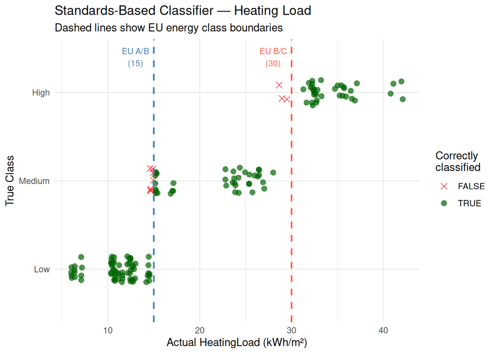

```r
results_HL_clf <- rbind(results_HL_clf,
  data.frame(Model = "Standards-Based (EU)", Accuracy = std_HL_result$accuracy))

p_std_HL <- data.frame(
  HeatingLoad     = df_test_clf$HeatingLoad,
  True_Class      = test_HL$HL_class,
  Predicted_Class = standards_pred_HL,
  Correct         = (test_HL$HL_class == standards_pred_HL)
) %>%
  ggplot(aes(x = HeatingLoad, y = True_Class, colour = Correct, shape = Correct)) +
  geom_jitter(height = 0.15, alpha = 0.7, size = 2.5) +
  geom_vline(xintercept = 15, linetype = "dashed", colour = "steelblue", linewidth = 0.8) +
  geom_vline(xintercept = 30, linetype = "dashed", colour = "tomato",   linewidth = 0.8) +
  scale_colour_manual(values = c("TRUE" = "darkgreen", "FALSE" = "red"),
                      name = "Correctly\nclassified") +
  scale_shape_manual(values  = c("TRUE" = 16, "FALSE" = 4),
                     name = "Correctly\nclassified") +
  annotate("text", x = 13, y = 3.4, label = "EU A/B\n(15)", size = 3, colour = "steelblue") +
  annotate("text", x = 28, y = 3.4, label = "EU B/C\n(30)", size = 3, colour = "tomato") +
  labs(title    = "Standards-Based Classifier — Heating Load",
       subtitle = "Dashed lines show EU energy class boundaries",
       x = "Actual HeatingLoad (kWh/m²)", y = "True Class") +
  theme_minimal()
print(p_std_HL)
```

```r
standards_pred_CL <- case_when(
  df_test_clf$CoolingLoad < 15 ~ "Low",
  df_test_clf$CoolingLoad < 30 ~ "Medium",
  TRUE                         ~ "High"
) %>% factor(levels = c("Low", "Medium", "High"))

cat("=== STANDARDS-BASED CLASSIFIER — Cooling Load ===\n")
```

```
## === STANDARDS-BASED CLASSIFIER — Cooling Load ===
```

```r
std_CL_result <- eval_clf(test_CL$CL_class, standards_pred_CL, "Standards-Based (EU)")
```

```
## Standards-Based (EU)                 Accuracy = 0.8618
```

```r
cat("\nConfusion matrix:\n")
```

```
##
## Confusion matrix:
```

```r
print(std_CL_result$confusion)
```

```
##         Predicted
## Actual   Low Medium High
##   Low     44     21    0
##   Medium   0     45    0
##   High     0      0   42
```

```r
results_CL_clf <- rbind(results_CL_clf,
  data.frame(Model = "Standards-Based (EU)", Accuracy = std_CL_result$accuracy))
```

## 6.7 Model 2 — Ordinal Random Forest

Standard classification models treat the three energy classes as unrelated categories: a two-step error (Low → High) costs the same as a one-step error (Low → Medium). A building engineer acting on these predictions would make very different decisions depending on error direction, so this symmetry is a problem.

The `ranger` probability forest below is trained to return class probabilities, from which the Ranked Probability Score (RPS) is computed. RPS penalises the cumulative distance between the predicted probability distribution and the true class, so two-step errors carry a higher penalty than one-step errors.

```r
cat("=== ORDINAL RANDOM FOREST — Heating Load ===\n")
```

```
## === ORDINAL RANDOM FOREST — Heating Load ===
```

```r
cat("Training model...\n")
```

```
## Training model...
```

```r
train_HL_ranger <- train_HL_ord
train_HL_ranger$HL_class_ord <- factor(
  as.character(train_HL_ord$HL_class_ord),
  levels = c("Low","Medium","High"), ordered = FALSE
)
test_HL_ranger <- test_HL_ord
test_HL_ranger$HL_class_ord <- factor(
  as.character(test_HL_ord$HL_class_ord),
  levels = c("Low","Medium","High"), ordered = FALSE
)

set.seed(42)
orf_y1 <- ranger(
  dependent.variable.name = "HL_class_ord",
  data                    = train_HL_ranger,
  num.trees               = 500,
  mtry                    = floor(sqrt(length(features))),
  min.node.size           = 5,
  probability             = TRUE,
  importance              = "impurity",
  num.threads             = parallel::detectCores() - 1
)

pred_prob_orf_y1  <- predict(orf_y1, data = test_HL_ranger)$predictions
pred_prob_orf_y1  <- pred_prob_orf_y1[, c("Low","Medium","High")]
pred_class_orf_y1 <- factor(
  colnames(pred_prob_orf_y1)[apply(pred_prob_orf_y1, 1, which.max)],
  levels = c("Low","Medium","High")
)

orf_HL_result <- eval_clf(test_HL$HL_class, pred_class_orf_y1, "Ordinal Random Forest")
```

```
## Ordinal Random Forest                Accuracy = 0.9408
```

```r
cat("\nConfusion matrix:\n")
```

```
##
## Confusion matrix:
```

```r
print(orf_HL_result$confusion)
```

```
##         Predicted
## Actual   Low Medium High
##   Low     60      8    0
##   Medium   0     44    1
##   High     0      0   39
```

```r
rps_orf_HL <- ranked_prob_score(
  pred_prob_orf_y1,
  factor(test_HL$HL_class, levels = c("Low","Medium","High"), ordered = TRUE)
)
cat(sprintf("\nRanked Probability Score: %.5f\n", rps_orf_HL))
```

```
##
## Ranked Probability Score: 0.01624
```

```r
cat("(Lower is better; RPS = 0 means every building classified perfectly)\n")
```

```
## (Lower is better; RPS = 0 means every building classified perfectly)
```

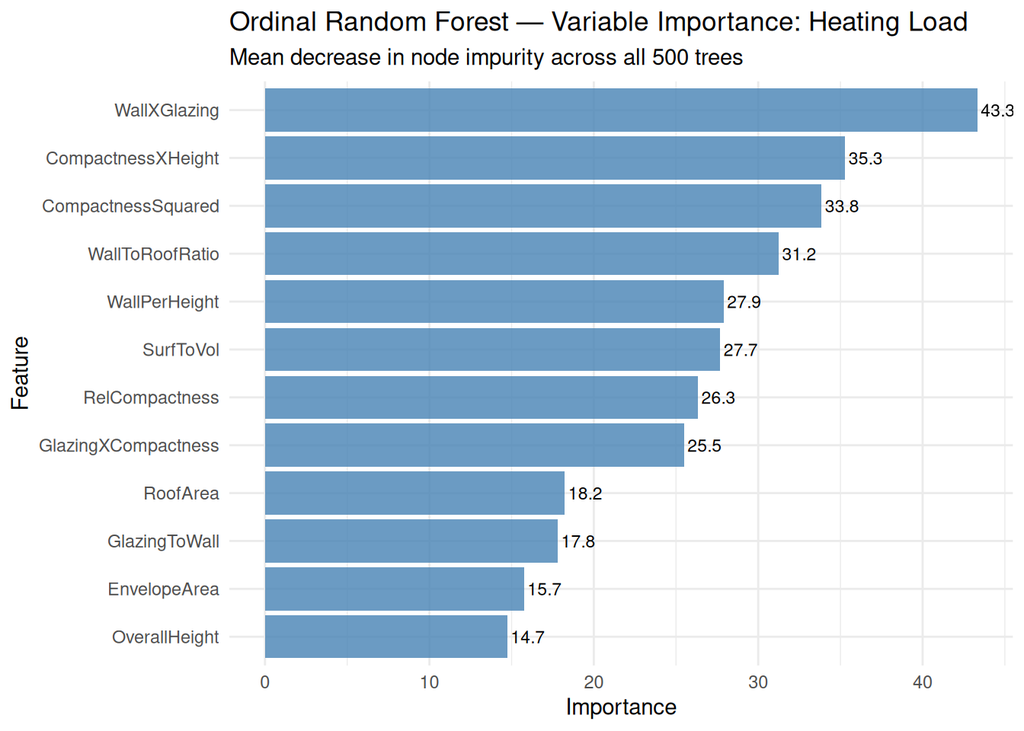

```r
results_HL_clf <- rbind(results_HL_clf,
  data.frame(Model = "Ordinal Random Forest", Accuracy = orf_HL_result$accuracy))

# Variable importance
orf_imp_y1 <- data.frame(
  Feature    = names(orf_y1$variable.importance),
  Importance = orf_y1$variable.importance
) %>% arrange(desc(Importance)) %>% head(12)

ggplot(orf_imp_y1, aes(x = reorder(Feature, Importance), y = Importance)) +
  geom_col(fill = "steelblue", alpha = 0.8) +
  geom_text(aes(label = round(Importance, 1)), hjust = -0.1, size = 3) +
  coord_flip() +
  labs(title    = "Ordinal Random Forest — Variable Importance: Heating Load",
       subtitle = "Mean decrease in node impurity across all 500 trees",
       x = "Feature", y = "Importance") +
  theme_minimal()
```

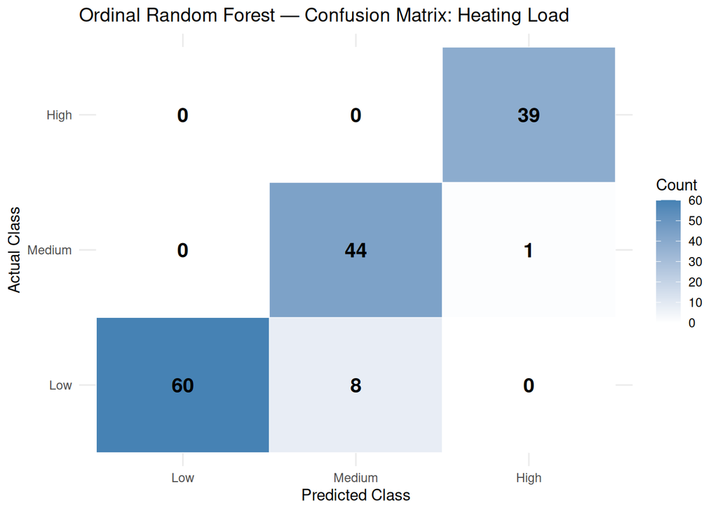

```r
# Confusion matrix heatmap
as.data.frame(orf_HL_result$confusion) %>% rename(Count = Freq) %>%
  ggplot(aes(x = Predicted, y = Actual, fill = Count)) +
  geom_tile(colour = "white") +
  geom_text(aes(label = Count), size = 5, fontface = "bold") +
  scale_fill_gradient(low = "white", high = "steelblue") +
  labs(title = "Ordinal Random Forest — Confusion Matrix: Heating Load",
       x = "Predicted Class", y = "Actual Class") +
  theme_minimal()
```

```r
train_CL_ranger <- train_CL_ord
train_CL_ranger$CL_class_ord <- factor(
  as.character(train_CL_ord$CL_class_ord),
  levels = c("Low","Medium","High"), ordered = FALSE
)
test_CL_ranger <- test_CL_ord
test_CL_ranger$CL_class_ord <- factor(
  as.character(test_CL_ord$CL_class_ord),
  levels = c("Low","Medium","High"), ordered = FALSE
)

set.seed(42)
orf_y2 <- ranger(
  dependent.variable.name = "CL_class_ord",
  data                    = train_CL_ranger,
  num.trees               = 500,
  mtry                    = floor(sqrt(length(features))),
  min.node.size           = 5,
  probability             = TRUE,
  importance              = "impurity",
  num.threads             = parallel::detectCores() - 1
)

pred_prob_orf_y2  <- predict(orf_y2, data = test_CL_ranger)$predictions
pred_prob_orf_y2  <- pred_prob_orf_y2[, c("Low","Medium","High")]
pred_class_orf_y2 <- factor(
  colnames(pred_prob_orf_y2)[apply(pred_prob_orf_y2, 1, which.max)],
  levels = c("Low","Medium","High")
)

orf_CL_result <- eval_clf(test_CL$CL_class, pred_class_orf_y2, "Ordinal Random Forest")
```

```
## Ordinal Random Forest                Accuracy = 0.9276
```

```r
cat("\nConfusion matrix:\n")
```

```
##
## Confusion matrix:
```

```r
print(orf_CL_result$confusion)
```

```
##         Predicted
## Actual   Low Medium High
##   Low     60      5    0
##   Medium   0     43    2
##   High     0      4   38
```

```r
rps_orf_CL <- ranked_prob_score(
  pred_prob_orf_y2,
  factor(test_CL$CL_class, levels = c("Low","Medium","High"), ordered = TRUE)
)
cat(sprintf("\nRanked Probability Score: %.5f\n", rps_orf_CL))
```

```
##
## Ranked Probability Score: 0.02463
```

```r
results_CL_clf <- rbind(results_CL_clf,
  data.frame(Model = "Ordinal Random Forest", Accuracy = orf_CL_result$accuracy))
```

## 6.8 Ordinal Error Analysis

One advantage of ordinal classification is the ability to break errors down by severity. This section computes the error distance distribution by finding how many of each model’s mistakes were one class off versus two classes off.

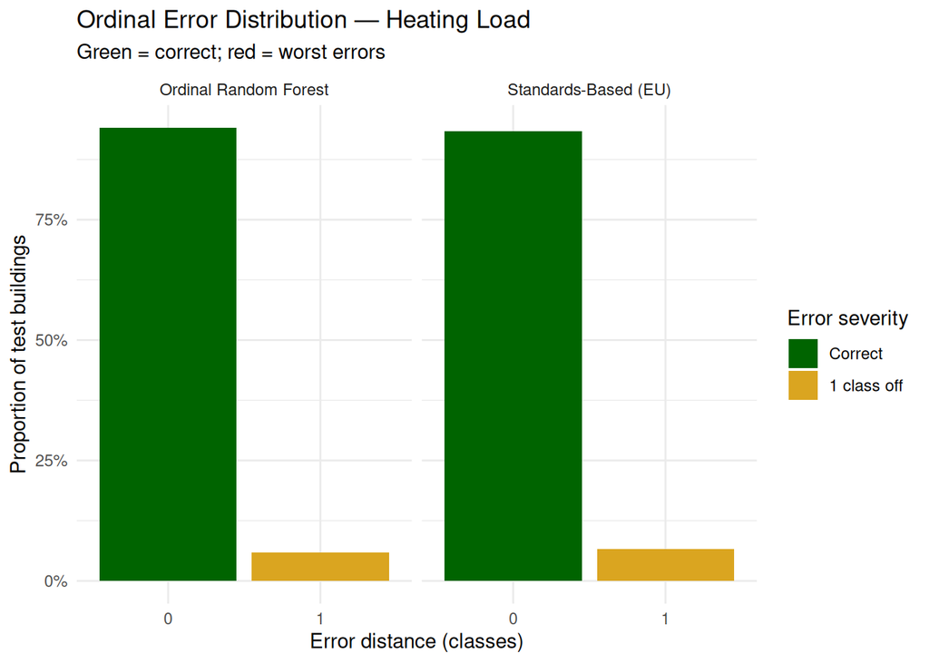

```r
ordinal_distance <- function(actual, predicted) {
  class_order <- c("Low" = 1, "Medium" = 2, "High" = 3)
  abs(class_order[as.character(actual)] - class_order[as.character(predicted)])
}

error_dist_HL <- data.frame(
  Model = c(rep("Standards-Based (EU)", nrow(test_HL)),
            rep("Ordinal Random Forest", nrow(test_HL))),
  Distance = c(
    ordinal_distance(test_HL$HL_class, standards_pred_HL),
    ordinal_distance(test_HL$HL_class, pred_class_orf_y1)
  )
)

error_dist_HL %>%
  group_by(Model, Distance) %>%
  summarise(Count = n(), .groups = "drop") %>%
  group_by(Model) %>%
  mutate(Proportion = Count / sum(Count)) %>%
  ggplot(aes(x = factor(Distance), y = Proportion,
             fill = factor(Distance))) +
  geom_col() +
  facet_wrap(~Model, ncol = 2) +
  scale_fill_manual(
    values = c("0" = "darkgreen", "1" = "goldenrod", "2" = "tomato"),
    labels = c("0" = "Correct", "1" = "1 class off", "2" = "2 classes off"),
    name   = "Error severity"
  ) +
  scale_y_continuous(labels = scales::percent) +
  labs(title    = "Ordinal Error Distribution — Heating Load",
       subtitle = "Green = correct; red = worst errors",
       x = "Error distance (classes)", y = "Proportion of test buildings") +
  theme_minimal()
```

## 6.9 Classification Model Comparison

```r
results_HL_clf <- results_HL_clf %>% arrange(desc(Accuracy))
results_CL_clf <- results_CL_clf %>% arrange(desc(Accuracy))

cat("=== HEATING LOAD — Classification Comparison ===\n")
```

```
## === HEATING LOAD — Classification Comparison ===
```

```r
print(results_HL_clf, row.names = FALSE)
```

```
##                  Model  Accuracy
##  Ordinal Random Forest 0.9407895
##   Standards-Based (EU) 0.9342105
```

```r
cat("\n=== COOLING LOAD — Classification Comparison ===\n")
```

```
##
## === COOLING LOAD — Classification Comparison ===
```

```r
print(results_CL_clf, row.names = FALSE)
```

```
##                  Model  Accuracy
##  Ordinal Random Forest 0.9276316
##   Standards-Based (EU) 0.8618421
```

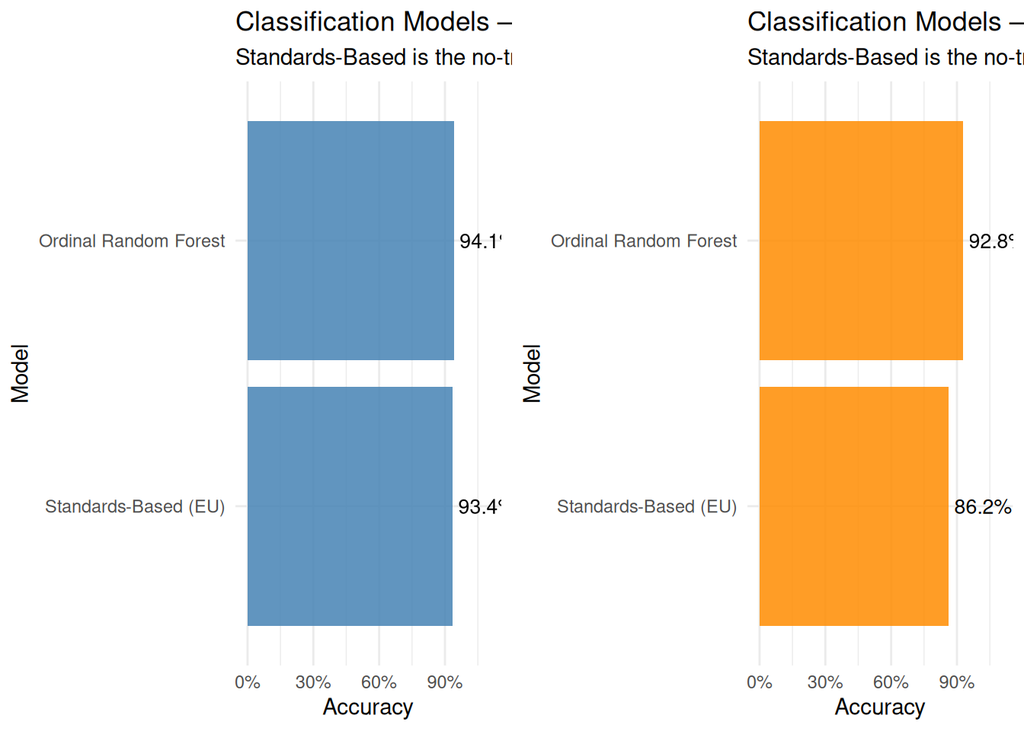

```r
p_clf_HL <- ggplot(results_HL_clf,
                    aes(x = reorder(Model, Accuracy), y = Accuracy)) +
  geom_col(fill = "steelblue", alpha = 0.85) +
  geom_text(aes(label = paste0(round(Accuracy * 100, 1), "%")),
            hjust = -0.1, size = 3.5) +
  coord_flip() +
  scale_y_continuous(limits = c(0, 1.1), labels = scales::percent) +
  labs(title    = "Classification Models — Accuracy: Heating Load",
       subtitle = "Standards-Based is the no-training domain baseline",
       x = "Model", y = "Accuracy") +
  theme_minimal()

p_clf_CL <- ggplot(results_CL_clf,
                    aes(x = reorder(Model, Accuracy), y = Accuracy)) +
  geom_col(fill = "darkorange", alpha = 0.85) +
  geom_text(aes(label = paste0(round(Accuracy * 100, 1), "%")),
            hjust = -0.1, size = 3.5) +
  coord_flip() +
  scale_y_continuous(limits = c(0, 1.1), labels = scales::percent) +
  labs(title    = "Classification Models — Accuracy: Cooling Load",
       subtitle = "Standards-Based is the no-training domain baseline",
       x = "Model", y = "Accuracy") +
  theme_minimal()

grid.arrange(p_clf_HL, p_clf_CL, ncol = 2)
```

# 7 Part 5 — Cross-Model Comparison and Conclusions

## 7.1 Regression: All Models Side by Side

This section brings together the linear baselines from Part 2 and the domain-appropriate regression results from Part 3 into a single comparison. All metrics are on the same held-out test set (the 20% group-aware holdout, set.seed=42).

```r
# Heating load — full summary including linear models
reg_summary_HL <- bind_rows(
  results_HL %>%
    mutate(Family = "Linear (Part 2)") %>%
    rename(RMSE_val = RMSE, MAE_val = MAE, R2_val = R2),
  results_y1 %>%
    mutate(Family = ifelse(grepl("Baseline", Model), "Linear (Part 2)",
                           "Domain-Appropriate (Part 3)")) %>%
    rename(RMSE_val = RMSE, MAE_val = MAE, R2_val = R2)
) %>% distinct(Model, .keep_all = TRUE)

cat("=== FULL REGRESSION COMPARISON — Heating Load ===\n")
```

```
## === FULL REGRESSION COMPARISON — Heating Load ===
```

```r
print(reg_summary_HL %>% arrange(RMSE_val) %>%
        select(Model, Family, RMSE_val, MAE_val, R2_val), row.names = FALSE)
```

```
##                          Model                      Family  RMSE_val   MAE_val
##                       LightGBM Domain-Appropriate (Part 3) 0.5191478 0.3824274
##                           MARS Domain-Appropriate (Part 3) 0.6378071 0.4938596
##           Quantile RF (median) Domain-Appropriate (Part 3) 1.1114237 0.5774605
##                      GPR (RBF) Domain-Appropriate (Part 3) 1.1234017 0.8146936
##                      SVR (RBF) Domain-Appropriate (Part 3) 1.1245770 0.8436601
##                  GPR (Laplace) Domain-Appropriate (Part 3) 2.0339059 1.3848958
##                    Elastic Net             Linear (Part 2) 2.4278437 1.7598254
##  Linear Baseline (Elastic Net)             Linear (Part 2) 2.4280000 1.7600000
##          OLS with Interactions             Linear (Part 2) 2.4698813 1.7677054
##               Ridge Regression             Linear (Part 2) 2.5458216 1.8352670
##               Lasso Regression             Linear (Part 2) 2.5631828 1.8084286
##                   Baseline OLS             Linear (Part 2) 2.8395973 2.1577934
##     R2_val
##  0.9973085
##  0.9959375
##  0.9876641
##  0.9873968
##  0.9873704
##  0.9586884
##  0.9411358
##  0.9411000
##  0.9390797
##  0.9352759
##  0.9343901
##  0.9194763
```

```r
# Cooling load
reg_summary_CL <- bind_rows(
  results_CL %>%
    mutate(Family = "Linear (Part 2)") %>%
    rename(RMSE_val = RMSE, MAE_val = MAE, R2_val = R2),
  results_y2 %>%
    mutate(Family = ifelse(grepl("Baseline", Model), "Linear (Part 2)",
                           "Domain-Appropriate (Part 3)")) %>%
    rename(RMSE_val = RMSE, MAE_val = MAE, R2_val = R2)
) %>% distinct(Model, .keep_all = TRUE)

cat("\n=== FULL REGRESSION COMPARISON — Cooling Load ===\n")
```

```
##
## === FULL REGRESSION COMPARISON — Cooling Load ===
```

```r
print(reg_summary_CL %>% arrange(RMSE_val) %>%
        select(Model, Family, RMSE_val, MAE_val, R2_val), row.names = FALSE)
```

```
##                    Model                      Family RMSE_val  MAE_val
##                     MARS Domain-Appropriate (Part 3) 1.538647 1.050773
##                 LightGBM Domain-Appropriate (Part 3) 1.639926 1.131837
##     Quantile RF (median) Domain-Appropriate (Part 3) 1.879722 1.161184
##                GPR (RBF) Domain-Appropriate (Part 3) 2.026035 1.502672
##                SVR (RBF) Domain-Appropriate (Part 3) 2.262325 1.697683
##            GPR (Laplace) Domain-Appropriate (Part 3) 2.503031 1.711321
##         Ridge Regression             Linear (Part 2) 2.887706 2.060452
##  Linear Baseline (Ridge)             Linear (Part 2) 2.888000 2.060000
##              Elastic Net             Linear (Part 2) 2.931683 2.180751
##    OLS with Interactions             Linear (Part 2) 2.978057 2.057406
##         Lasso Regression             Linear (Part 2) 2.982344 2.150472
##             Baseline OLS             Linear (Part 2) 3.161479 2.305773
##     R2_val
##  0.9723434
##  0.9685827
##  0.9587230
##  0.9520472
##  0.9402097
##  0.9268098
##  0.9025849
##  0.9026000
##  0.8995952
##  0.8963936
##  0.8960951
##  0.8832381
```

[figure not shown]

```r
# Visual
p_all_HL <- ggplot(reg_summary_HL %>% arrange(RMSE_val),
                    aes(x = reorder(Model, RMSE_val), y = RMSE_val, fill = Family)) +
  geom_col(alpha = 0.85) +
  geom_text(aes(label = round(RMSE_val, 3)), hjust = -0.1, size = 3) +
  coord_flip() +
  scale_fill_manual(values = c("Linear (Part 2)" = "steelblue",
                                "Domain-Appropriate (Part 3)" = "tomato")) +
  labs(title    = "All Regression Models — RMSE: Heating Load",
       subtitle = "Blue = linear; red = domain-appropriate",
       x = "Model", y = "RMSE (kWh/m²)", fill = NULL) +
  theme_minimal()

p_all_CL <- ggplot(reg_summary_CL %>% arrange(RMSE_val),
                    aes(x = reorder(Model, RMSE_val), y = RMSE_val, fill = Family)) +
  geom_col(alpha = 0.85) +
  geom_text(aes(label = round(RMSE_val, 3)), hjust = -0.1, size = 3) +
  coord_flip() +
  scale_fill_manual(values = c("Linear (Part 2)" = "steelblue",
                                "Domain-Appropriate (Part 3)" = "darkorange")) +
  labs(title    = "All Regression Models — RMSE: Cooling Load",
       subtitle = "Blue = linear; orange = domain-appropriate",
       x = "Model", y = "RMSE (kWh/m²)", fill = NULL) +
  theme_minimal()

grid.arrange(p_all_HL, p_all_CL, ncol = 2)
```